# “Titanic EDA”

# ** COLUMN 6: Parch AND SibSp and Family_Size (Family_Size is the sume of Parch and Sibsp)

# COLUMN 7: Passenger ID – just a 3 digit number, not associated with anything on board the ship, so not analyzed

# ** COLUMN 8: Pclass - need to plot Pclass 1,2,3 vs. Survived

# ** COLUMN 9: Sex - clearly a primary factor

# COLUMN 10: SibSp - see above for column 6

# COLUMN 11: Survived - this is the outcome (y value) for all the other single variables, so no analysis ofit as an x-variable

# COLUMN 12: Ticket - lots of random numbers, no trend that can be analyzed

# COLUMN 13: Title - already analyzed above as Name

# COLUMN 14: Family_Size - see above for col 6, analyze with Parch and SibSp

# COLUMN 15: Cabin_deck - already analyzed as Cabin

# So that leaves 3 things (THE ONES WITH ** ABOVE) left for single variable analysis

### Let’s start with *** COLUMN 6,10,14 = Parch, SibSp and Family_Size ****

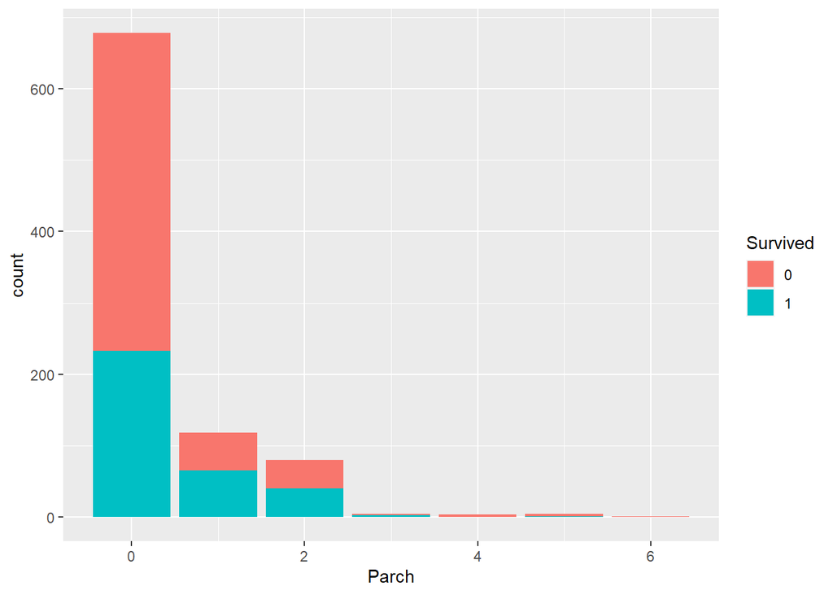

```r
## *** FAMILY_SIZE *** reinitialize (note this will result in no Col 15, but we don't need Cabin_deck for this section  COMPLETE
library(tidyverse)
library(readxl)
library(stringr)
library(dplyr)
library(ggplot2)
titanic <- read_xlsx('titanic_partial.xlsx')
titanic$Title <- as.factor(titanic$Title)
titanic$Survived <- as.factor(titanic$Survived)
### When we plot it just by Parch, note that if Parch =0 (no parent or children traveling with them) then their probability
### of surviving looked worse, which makes sense that they would save families first.  But it could be that those single people
### were men traveling alone, which died more
ggplot(data=titanic) +
  geom_bar(mapping = aes(x = Parch, fill = Survived))
```

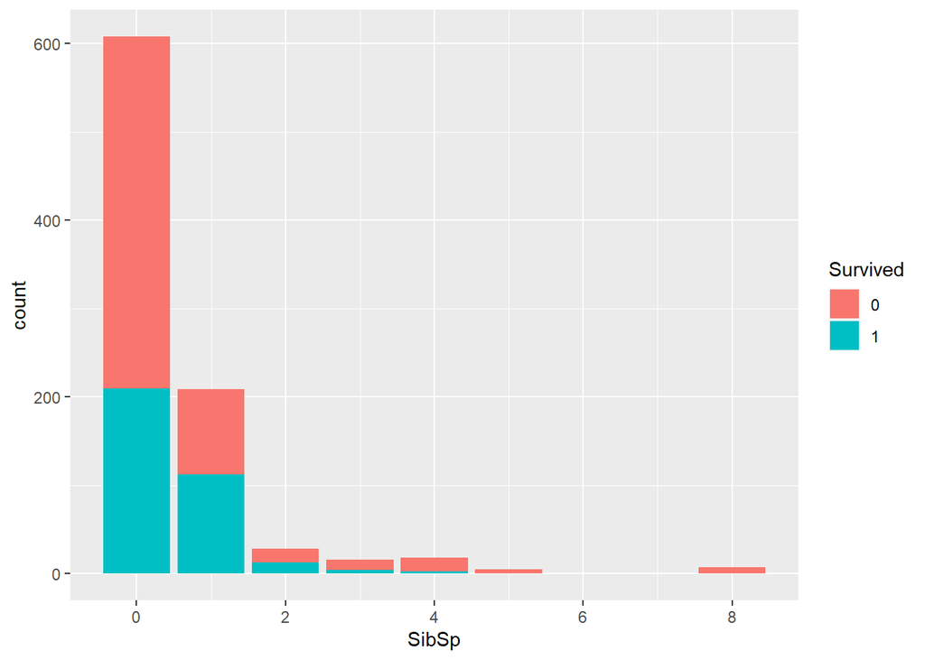

```r
### This single plot of SibSp (siblings and spouses) had pretty much the same result that people traveling solo fared worse,
### but again it could be mostly men traveling solo, and it's really gender that is the affect.  Obviously statistically, each
### time you add a person, there's a probability it's a woman - there were 36% women and 64% men on the Titanic (assuming
### that Rev and Dr were men, so if you add Parch or SibSp, with each add there's a 35% it's a woman)
ggplot(data=titanic) +
  geom_bar(mapping = aes(x = SibSp, fill = Survived))
```

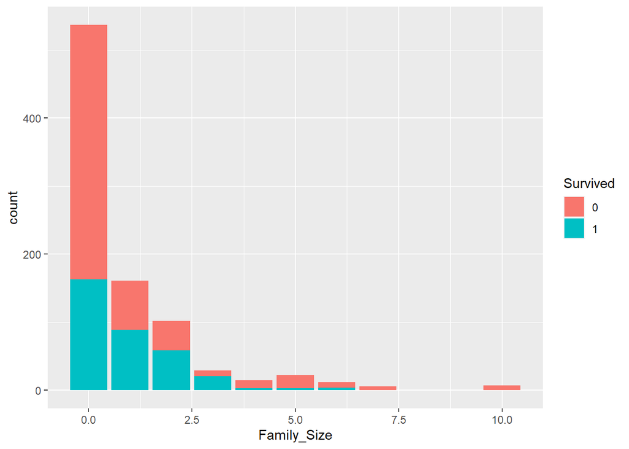

```r
### Ok, third graph is the sum of SibSp and Parch, which is Family_Size (column 14).  This sums up this group of variables
### well, showing if someone is traveling alone, they are far more likely not to survive, and if they travel in a moderate sized ### group, their odds get better, but in the really large groups, it might not have been possible to save everyone.
ggplot(data=titanic) +
  geom_bar(mapping = aes(x = Family_Size, fill = Survived))
```

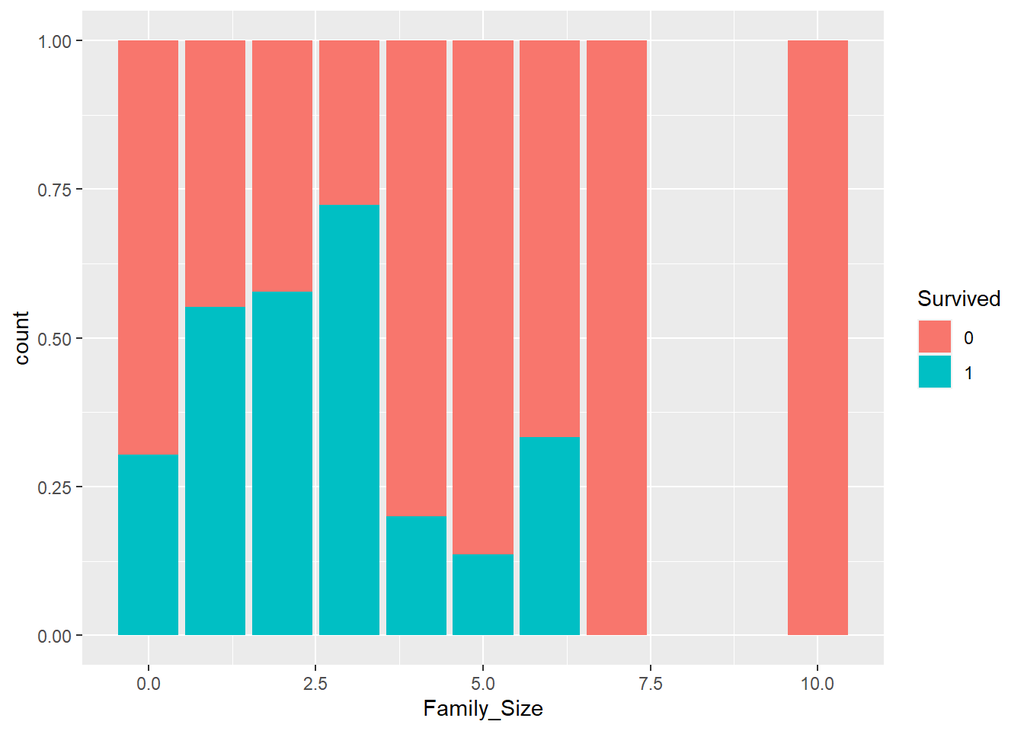

```r
# Let's do a stacked barchart to evaluated proportion next.
# It shows that yes, people traveling alone Survived poorly, but so did Family_Size of 4 and 5, but we see
# zero Survived for family sizes of 7 and 10 (probably weren't willing to leave family behind).  The best case
# Survival was Family_Size 1,2 and 3 in terms of proportionate odds.
ggplot(data=titanic) +
  geom_bar(mapping = aes(x = Family_Size, fill = Survived),
           position = "fill")
```

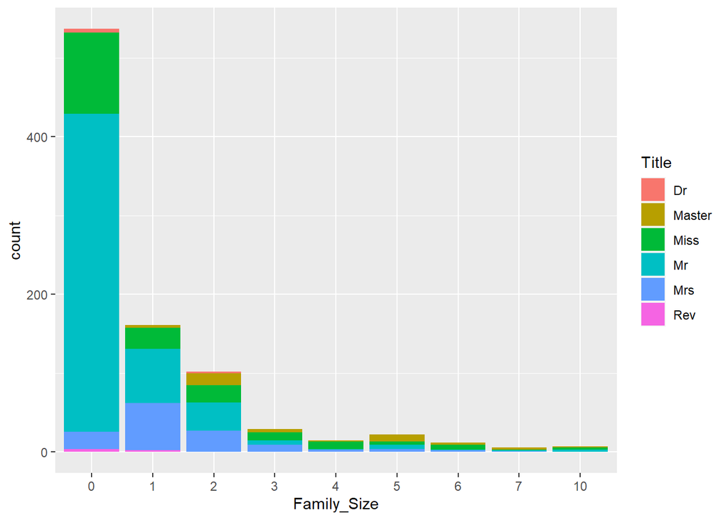

```r
### now LETS TRY PLOTTING FAMILY_SIZE VS. TITLE AND SURVIVED.  The plot created shows that for a family size of zero
### singles traveling alone, the majority of them (turquoise) were "Mr", and only a minority were "Mrs", so that confirms
### that part of the reason people traveling alone died were because they were men, not just because they were alone.
### If you look at the Family_Size (3rd chart) when Family_Size = 0, there are about 550 of those, and approximately 160
### out of 550 survived, or 29% (ball park).  For the chart below, there are again about 550 with zero Family_Size and about
### 130 people are Miss or Mrs, so 130/550 = ~ 24%. So that tells you most of the zero family size people that survived are
### women and single men didn't do well on surviving.
titanic$Family_Size<-as.factor(titanic$Family_Size)
titanic$Title <- as.factor(titanic$Title)
titanic$Survived <- as.character(titanic$Survived)

ggplot(data = titanic, mapping = aes(x = Family_Size, fill = Title)) +
         geom_bar()
```

```r
### THIS SECTION COMPLETE                                                                                   COMPLETE
```

### COLUMN 8 : Pclass **** possible classes are 1,2,3

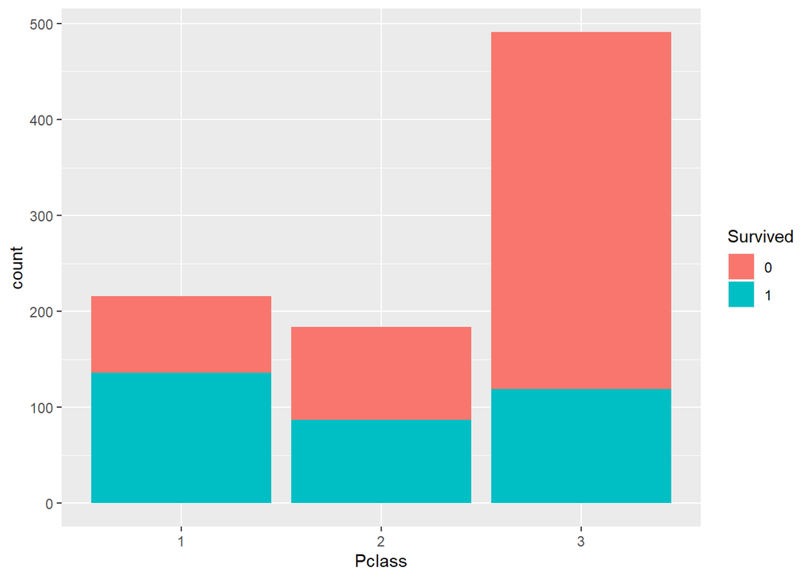

```r
### reinitialize everything (don't need col 15 Cabin_deck) just in case this block isn't done in order
library(tidyverse)
library(readxl)
library(stringr)
library(dplyr)
library(ggplot2)
titanic <- read_xlsx('titanic_partial.xlsx')
titanic$Pclass <- as.factor(titanic$Pclass)
titanic$Survived <- as.factor(titanic$Survived)
## Regular bar chart to show how each Pclass did.
## As expected, this shows that the Pclass 3 (low fare) passengers did not survive as well as the Pclass 1 and 2 did.
## Part of that could be that Pclass 1 and 2 only had about 200 in each class, whereas Pclass 3 has close to 500, so
## that is a lot more people to save.
ggplot(data=titanic) +
  geom_bar(mapping = aes(x = Pclass, fill = Survived))
```

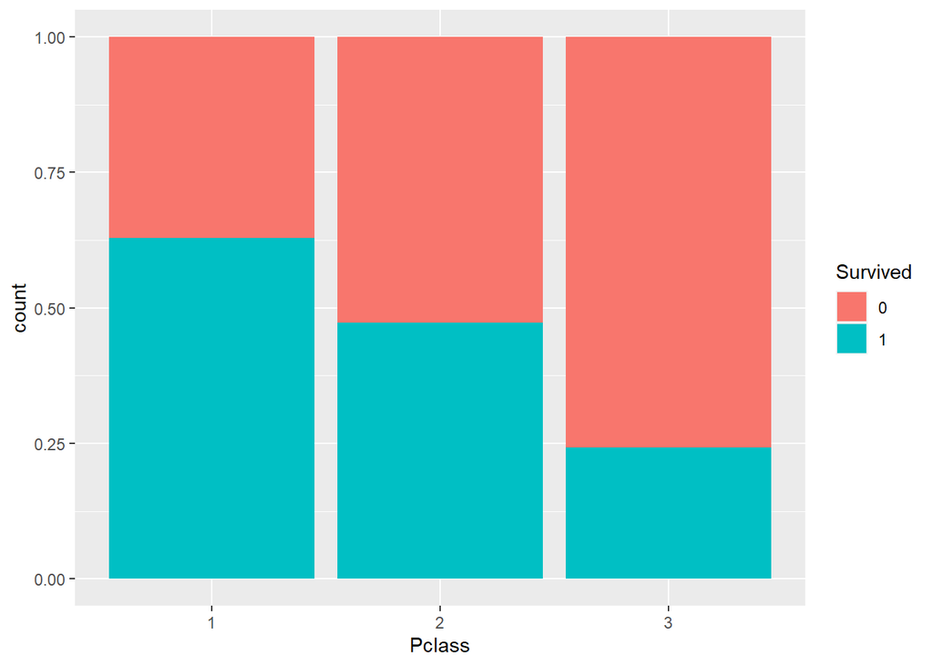

```r
## Stacked bar chart to show what proportion of each Pclass survived
## This confirms that the proportion that survived was best for Pclass 1, then Pclass 2 and in last was Pclass 3,
## which seems pretty predictive, since even though Pclass 1 and 2 had roughly the same number of people, the %
## survived was better for Pclass 1.
ggplot(data=titanic) +
  geom_bar(mapping = aes(x = Pclass, fill = Survived), position = "fill" )
```

```r
### THIS SECTION COMPLETE                                                                                   COMPLETE
```